# MVP 3

Advanced Geocomputation

Author

Matt Braaksma

# Climate Change and Coastal Housing Markets

## Description

Rising sea levels and more frequent storms pose significant risks to coastal infrastructure, yet housing markets often fail to reflect these growing threats. A key question emerges: how does the increasing likelihood of flooding impact housing prices? In particular, are homes in the vulnerable southern U.S. overvalued despite their heightened exposure to these risks?

The key task for this MVP is incorporating parallel processing into the workflow:

1. Read county parcels shape file
2. Gather and aggregate OSM building height data
3. Calculate zonal statistics to obtain the average probability by parcel
   - Most computationally expensive task

## Code

### 1. Import modules

Import the necessary data, geospatial, visualization modules.

```python
# Standard Library Imports
import os
import numpy as np
import pandas as pd

# Geospatial Data Imports
import geopandas as gpd
import osmnx as ox
import rasterio
from rasterstats import zonal_stats
from pyogrio import read_dataframe

# Parallel Processing Imports
from multiprocess import Pool
```

## Define OSM functions

```python
def fetch_osm_buildings(place, tags, crs):
    """Fetch building data using OSMNx and transform to the given CRS."""
    print(f"Fetching OSM building data for {place}")
    buildings = ox.features_from_place(place, tags)
    return buildings.to_crs(crs)

def aggregate_building_data(parcels, buildings):
    """Aggregate building data (count and average height) within parcels."""
    print("Aggregating building data")
    # Perform spatial join to assign buildings to parcels
    joined = gpd.sjoin(buildings, parcels, how='inner', predicate='within')

    # Ensure height is numeric (OSM data can have it as a string)
    joined['height'] = pd.to_numeric(joined['height'], errors='coerce')

    # Aggregate data: count buildings and compute average height
    aggregated = (
        joined.groupby('index_right')
        .agg(
            num_buildings=('height', 'size'),
            avg_height=('height', 'mean')
        )
        .reset_index()
    )

    # Merge the aggregated data back into the parcels DataFrame
    parcels = parcels.merge(aggregated, left_index=True, right_on='index_right', how='left')

    # Fill NaNs with 0 for parcels that had no buildings
    parcels['num_buildings'] = parcels['num_buildings'].fillna(0).astype(int)
    parcels['avg_height'] = parcels['avg_height'].fillna(0)

    return parcels
```

## Define Surge functions

```python
def load_raster_to_array(raster_path):
    """Load a raster as a NumPy array."""
    with rasterio.open(raster_path) as src:
        array = src.read(1)
        affine = src.transform
        nodata = src.nodata
    return array, affine, nodata

def calculate_zonal_stats(parcels, raster_path):
    """Calculate zonal statistics for a given raster and parcel geometries."""
    if not os.path.exists(raster_path):
        print(f"Raster file not found: {raster_path}")
        return [np.nan] * len(parcels)

    # Perform zonal statistics
    stats = zonal_stats(parcels.geometry, raster_path, stats='mean', nodata=np.nan)
    return [stat['mean'] if stat['mean'] is not None else np.nan for stat in stats]

def calculate_zonal_stats_parallel(args):
    """Wrapper function for parallel processing."""
    parcels, raster_path = args
    return calculate_zonal_stats(parcels, raster_path)
```

## Define Surge functions

```python
def add_surge_data(parcels, surge_files, use_parallel=False):
    """Add surge data to parcels using either serial or parallel processing."""
    if use_parallel:
        print("Running in parallel mode...")
        with Pool() as pool:
            # Prepare arguments for each raster file
            args_list = [(parcels, path) for path in surge_files.values()]
            results = pool.map(calculate_zonal_stats_parallel, args_list)
        # Assign results to DataFrame columns
        for i, key in enumerate(surge_files.keys()):
            parcels[key] = results[i]
    else:
        print("Running in serial mode...")
        for key, path in surge_files.items():
            print(f"Calculating zonal stats for {key}")
            parcels[key] = calculate_zonal_stats(parcels, path)

    return parcels
```

## Define Paths and Load Data

```python
# Directory paths
data_dir = '/Users/mbraaksma/Files/base_data/coastal'
dare_parcel_path = os.path.join(data_dir, 'counties', 'NConemap', 'NC_Parcels_all.gdb')

# dare_parcels = read_dataframe(dare_parcel_path, layer='nc_parcels_poly', where="cntyname = 'Dare'") # Failed ro render in Quarto
dare_parcel_path = os.path.join(data_dir, 'counties', 'nc_dare')
dare_parcels = gpd.read_file(dare_parcel_path).to_crs("EPSG:4326")

# Flood surge raster paths
surge_files = {
    'surge_1ft': os.path.join(data_dir, 'surge_files', 'surge_probability_1ft_tracks_NA_era5_197901_202112_100_36-76'),
    'surge_5ft': os.path.join(data_dir, 'surge_files', 'surge_probability_5ft_tracks_NA_era5_197901_202112_100_36-76'),
    'surge_10ft': os.path.join(data_dir, 'surge_files', 'surge_probability_10ft_tracks_NA_era5_197901_202112_100_36-76'),
    'surge_20ft': os.path.join(data_dir, 'surge_files', 'surge_probability_20ft_tracks_NA_era5_197901_202112_100_36-76')
}

# Load all surge rasters into memory
raster_data = {}
for key, path in surge_files.items():
    if os.path.exists(path):
        print(f"Loading {key} raster")
        raster_data[key] = load_raster_to_array(path)
```

```
Loading surge_1ft raster
Loading surge_5ft raster
Loading surge_10ft raster
Loading surge_20ft raster
```

## Run **without** Parallel

```python
%%time

# Fetch the OSM building data
place = "Dare County, North Carolina"
tags = {"building": True}
osm_buildings = fetch_osm_buildings(place, tags, dare_parcels.crs)

# Aggregate building data within parcels
dare_parcels_with_buildings = aggregate_building_data(dare_parcels, osm_buildings)

# Add surge data to the parcels DataFrame
surge_keys = list(raster_data.keys())
dare_parcels_final = add_surge_data(dare_parcels_with_buildings, surge_files)
print('Finished processing data')
```

```
Fetching OSM building data for Dare County, North Carolina
Aggregating building data
Running in serial mode...
Calculating zonal stats for surge_1ft
Calculating zonal stats for surge_5ft
Calculating zonal stats for surge_10ft
Calculating zonal stats for surge_20ft
Finished processing data
CPU times: user 1min 46s, sys: 12.8 s, total: 1min 58s
Wall time: 1min 59s
```

## Run **with** Parallel

```python
%%time

# Fetch the OSM building data
place = "Dare County, North Carolina"
tags = {"building": True}
osm_buildings = fetch_osm_buildings(place, tags, dare_parcels.crs)

# Aggregate building data within parcels
dare_parcels_with_buildings = aggregate_building_data(dare_parcels, osm_buildings)

# Add surge data to the parcels DataFrame
surge_keys = list(raster_data.keys())
dare_parcels_final = add_surge_data(dare_parcels_with_buildings, surge_files, use_parallel=True)
print('Finished processing data')
```

```
Fetching OSM building data for Dare County, North Carolina
Aggregating building data
Running in parallel mode...
Finished processing data
CPU times: user 9.62 s, sys: 533 ms, total: 10.2 s
Wall time: 41.4 s
```

## Plot 1ft Surge Probabilities

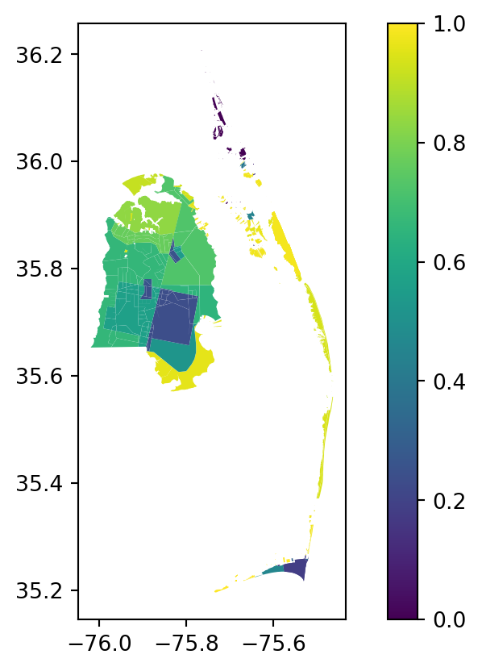

```python
dare_parcels_final.plot(column='surge_1ft', legend=True)
```

## Design Framework

#### Problem

How can parallel processing be incorporated into the workflow to improve processing time?

#### Solution

Answering this question requires a solid understanding of the multiprocessing library. The key is to understand which task is the most computationally expensive and adapt the code to incorporate a function that can be mapped in a parallel manner.

#### Challenge

Understanding how to implement the parallel processing libraries.

#### Spec list

| Spec | Value (H, M, L) | Effort (H, M, L) |
| --- | --- | --- |
| Read and preprocess county parcels shapefile | L | H |
| Aggregate and clean OSM building height data | M | H |
| Calculate zonal flood risk statistics by parcel | M | H |
| Integrate parallel processing for zonal statistics calculation | H | H |
| Integrate parallel processing using Dask | H | M |

#### Success

The goal of this MVP was to scale back and focus on understanding the incorporation of parallel processing into my workflow. Rather than tackling a larger problem and getting stuck on data-related challenges, I aimed to develop a foundational skillset. This MVP would be considered a success if I could effectively learn to integrate parallel processing in a way that can be reused in future projects.

#### Reflection

This MVP provided several key takeaways:

1. Improved Workflow Efficiency: I gained a deeper understanding of how to integrate parallel processing into my workflow. The time savings during development and troubleshooting were significant, highlighting the potential of these methods for future applications.
2. Efficient Spatial Data Loading: One challenge was loading a large geodatabase into memory. While the solution ultimately did not involve parallel processing, I discovered faster methods to filter and load spatial data into GeoPandas, which will be invaluable for similar tasks. (For some reason the pyogrio method worked in python, but failed to render in the quarto environment.)
3. Challenges with Dask: Despite efforts to incorporate Dask alongside multiprocessing, I encountered persistent challenges that I could not resolve during this MVP. Implementing Dask effectively remains an area for improvement and a future learning opportunity.

#### Conclusion

Overall, this MVP was a success. It allowed me to build a solid foundation for parallel processing and refine my approach to handling large datasets. Although there is room for growth, the lessons learned will serve as a stepping stone for future projects.